# lab8_HamnaAshraf

## 1. Get the data:

```python
#import required libraries

import pandas as pd
import matplotlib.pyplot as plt
import numpy as np
from sklearn.model_selection import train_test_split
from tensorflow import keras
from tensorflow.keras import layers
import tensorflow as tf
from sklearn.metrics import classification_report, confusion_matrix, precision_score, recall_score
```

```python
#Dowloaded files from Kaggle https://www.kaggle.com/code/abhishekyana/fmnist-dataset-with-cnns-tensorflow/data
train_df = pd.read_csv('./CSVs/fashion-mnist_train.csv')
test_df = pd.read_csv('./CSVs/fashion-mnist_test.csv')

#Another way to load fashion mnist data is as done in class notebook:
# from tensorflow.keras.datasets import fashion_mnist as fmnist
# (train_images, train_labels), (test_images, test_labels) = fmnist.load_data()
```

### Data Preprocessing:

**Let's look into the dataset to see how it looks like:**

```python
train_df.head()
```

|  | label | pixel1 | pixel2 | pixel3 | pixel4 | pixel5 | pixel6 | pixel7 | pixel8 | pixel9 | ... | pixel775 | pixel776 | pixel777 | pixel778 | pixel779 | pixel780 | pixel781 | pixel782 | pixel783 | pixel784 |
| --- | --- | --- | --- | --- | --- | --- | --- | --- | --- | --- | --- | --- | --- | --- | --- | --- | --- | --- | --- | --- | --- |
| 0 | 2 | 0 | 0 | 0 | 0 | 0 | 0 | 0 | 0 | 0 | ... | 0 | 0 | 0 | 0 | 0 | 0 | 0 | 0 | 0 | 0 |
| 1 | 9 | 0 | 0 | 0 | 0 | 0 | 0 | 0 | 0 | 0 | ... | 0 | 0 | 0 | 0 | 0 | 0 | 0 | 0 | 0 | 0 |
| 2 | 6 | 0 | 0 | 0 | 0 | 0 | 0 | 0 | 5 | 0 | ... | 0 | 0 | 0 | 30 | 43 | 0 | 0 | 0 | 0 | 0 |
| 3 | 0 | 0 | 0 | 0 | 1 | 2 | 0 | 0 | 0 | 0 | ... | 3 | 0 | 0 | 0 | 0 | 1 | 0 | 0 | 0 | 0 |
| 4 | 3 | 0 | 0 | 0 | 0 | 0 | 0 | 0 | 0 | 0 | ... | 0 | 0 | 0 | 0 | 0 | 0 | 0 | 0 | 0 | 0 |

5 rows × 785 columns

First column consists of the **labels**, whereas the rest are the image pixel values in columns **pixel1 - pixel784**.  
Let's split the data into labels and images.

```python
X_train = train_df.iloc[:, 1:].values
y_train = train_df.iloc[:, 0].values

X_test = test_df.iloc[:, 1:].values
y_test = test_df.iloc[:, 0].values
```

## 2. EDA:

If we check the description it mentions that each training and test example is assigned to one of the following labels:

0. T-shirt/top
1. Trouser
2. Pullover
3. Dress
4. Coat
5. Sandal
6. Shirt
7. Sneaker
8. Bag
9. Ankle boot

**Let's see an image in our training data and the label associated with it**

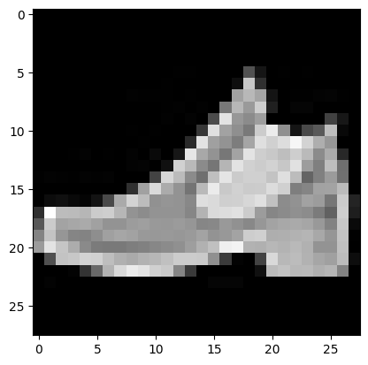

```python
plt.imshow(X_train[1].reshape(28,28), cmap='gray')
```

```python
print(y_train[1])
```

```
9
```

```python
def visualize_input(i, y):
    img = X_train[i].reshape(28,28)
    plt.imshow(img, cmap='gray')
    plt.title(f"Label : {y[i]}")
    width, height = img.shape
    thresh = img.max()/2.5
    for x in range(width):
        for y in range(height):
            plt.annotate(str(img[x][y]), xy=(y,x),
                        horizontalalignment='center',
                        verticalalignment='center',
                        color='white' if img[x][y]<thresh else 'black')
    plt.xticks([])
    plt.yticks([])
```

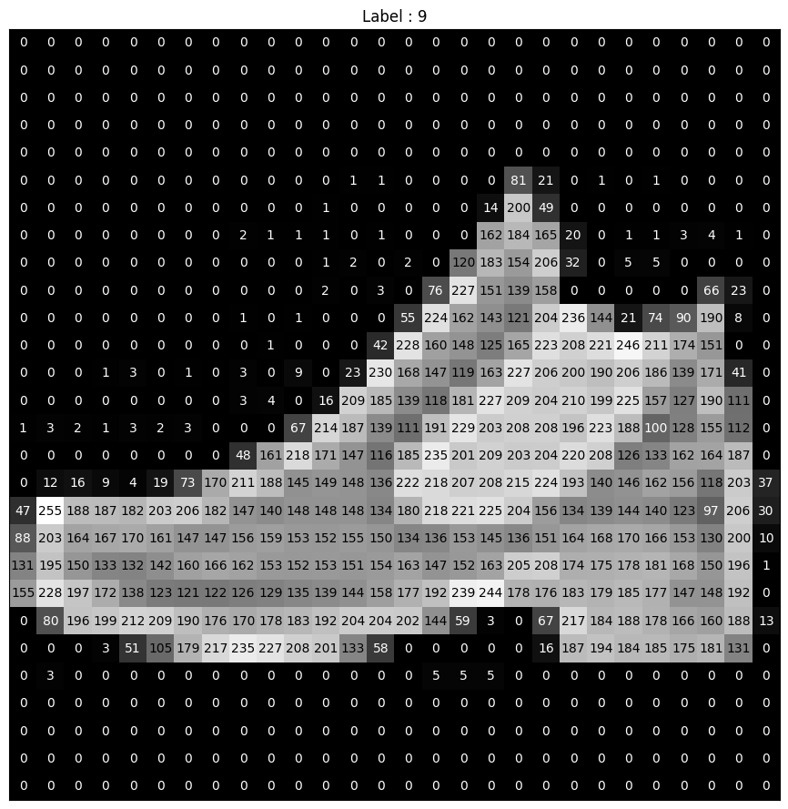

```python
fig = plt.figure(figsize = (15,11))
visualize_input(1, y_train)
```

The plot given above shows pixel values with colors. With these pixel values, we can see the shades in the image. Here 255 shows pure white color whereas less than 255 shows different shades of grey. 0 pixel value means pure black color whith is the background color in this case.

Now we will see how some of the other fashion items in our data set look like:

[figure not shown]

```python
class_names = ['T_shirt/top', 'Trouser', 'Pullover', 'Dress', 'Coat',
               'Sandal', 'Shirt', 'Sneaker', 'Bag', 'Ankle boot']
plt.figure(figsize=(10, 10))
for i in range(36):
    plt.subplot(6, 6, i + 1)
    plt.xticks([])
    plt.yticks([])
    plt.grid(False)
    plt.imshow(X_train[i].reshape((28,28)), cmap='gray')
    label_index = int(y_train[i])
    plt.title(class_names[label_index])
plt.show()

#Reference: https://www.kaggle.com/code/pavansanagapati/a-simple-cnn-model-beginner-guide
```

This plot is helpful in visualizing first 36 images in the training data. After this we can see visually how each image is different from the other and from it's own category.

**Data types and image data range:**

```python
print(f'Image Data Type: {type(X_train[0,0])}')
print(f'Label Data Type: {type(y_train[0])}')

print('\n**Shapes:**')
print('Train Data:')
print(f'Images: {X_train.shape}')
print(f'Labels: {y_train.shape}')
print('\nTest Data:')
print(f'Images: {X_test.shape}')
print(f'Labels: {y_test.shape}')

print('\n**Image Data Range:**')
print(f'Min: {X_train.min()}')
print(f'Max: {X_train.max()}')
```

```
Image Data Type: <class 'numpy.int64'>
Label Data Type: <class 'numpy.int64'>

**Shapes:**
Train Data:
Images: (60000, 784)
Labels: (60000,)

Test Data:
Images: (10000, 784)
Labels: (10000,)

**Image Data Range:**
Min: 0
Max: 255
```

We see that the image data ranges from 0-255. Therefore we need to normalize it.

**Normalize data:**

```python
X_train = X_train.astype("float32") / 255  # normalizing the data to the range [0,1] by min-max range, and casting it to float32
X_test = X_test.astype("float32") / 255
```

```python
print(f'Image data type: {type(X_train[0,0])}')
print(f'Label data type: {type(y_train[0])}')

print('\nImage Data Range:')
print(f'Min: {X_train.min()}')
print(f'Max: {X_train.max()}')
```

```
Image data type: <class 'numpy.float32'>
Label data type: <class 'numpy.int64'>

Image Data Range:
Min: 0.0
Max: 1.0
```

## 3. Define and train neural network:

**Split the data:**

```python
X_train, X_validate, y_train, y_validate = train_test_split(X_train, y_train, test_size=0.2, random_state=42)


print("Training: ",X_train.shape[0])
print("Validate: ",X_validate.shape[0])
print("Test:", X_test.shape[0])
```

```
Training:  48000
Validate:  12000
Test: 10000
```

#### Define model:

```python
model = keras.Sequential([
    layers.Dense(512, activation="relu"),
    layers.Dense(10, activation="softmax")
])
```

**Sequential**: Defines a sequence of layers in the neural network.  
**Dense**: Adds a layer of neurons  
Each layer of neurons need an activation function to tell them what to do. There are a lot of options, but just use these for now:

**ReLU** means:  
if x > 0:  
return x

else:  
return 0

**Compile model:**

```python
model.compile(optimizer="rmsprop",
              loss="sparse_categorical_crossentropy",
              metrics=["accuracy"])
```

**Optimizer** - This is how the model is updated based on the data it sees and its loss function.  
**Loss function** - This calculates how accurate the model is during training.  
**Metrics** - Used to monitor the training and testing steps.

#### Train model:

```python
history = model.fit(X_train, y_train, epochs=5, batch_size=128, validation_data=(X_validate,y_validate))
```

After fitting the model, we get accuracy equal to 89%.

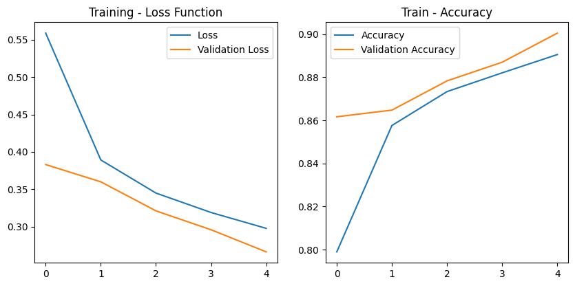

```python
plt.figure(figsize=(10, 10))

plt.subplot(2, 2, 1)
plt.plot(history.history['loss'], label='Loss')
plt.plot(history.history['val_loss'], label='Validation Loss')
plt.legend()
plt.title('Training - Loss Function')

plt.subplot(2, 2, 2)
plt.plot(history.history['accuracy'], label='Accuracy')
plt.plot(history.history['val_accuracy'], label='Validation Accuracy')
plt.legend()
plt.title('Train - Accuracy')
```

This plot shows the loss and accuracy fluctuations for each epoch for both training and validation data.  
For loss graph, we can see that initially the loss was high (almost 0.6) for the 1st epoch, however it gradually decreased after each epoch run to less than 0.3.

In the accuracy graph, we can also see a gradual increase in both the training and validation data accuracy which is more than 0.88 i.e it is more than 88% accurate.

## 4. Evaluate model on Validation data:

```python
y_pred = model.predict(X_validate)
predicted_classes = np.argmax(y_pred, axis=1)

target_names = ["Class {}".format(i) for i in range(10)]

print(classification_report(y_validate, predicted_classes, target_names=target_names))
```

```
              precision    recall  f1-score   support

     Class 0       0.80      0.92      0.86      1232
     Class 1       1.00      0.97      0.98      1174
     Class 2       0.86      0.80      0.83      1200
     Class 3       0.89      0.92      0.91      1242
     Class 4       0.81      0.83      0.82      1185
     Class 5       0.99      0.97      0.98      1141
     Class 6       0.75      0.68      0.71      1243
     Class 7       0.96      0.98      0.97      1224
     Class 8       0.99      0.97      0.98      1149
     Class 9       0.97      0.98      0.97      1210

    accuracy                           0.90     12000
   macro avg       0.90      0.90      0.90     12000
weighted avg       0.90      0.90      0.90     12000
```

This shows the precision, recall, f1score values for each fashion item.  
Let's calculate the accuracy of each item:

**Accuracy per class:**

```python
cm = confusion_matrix(y_validate, predicted_classes)
class_accuracy = cm.diagonal() / cm.sum(axis=1)

# Print accuracy for each class
label_names = ["Class {}".format(i) for i in range(10)]
print("Accuracy on validation data:\n")
for i, accuracy in enumerate(class_accuracy):
    print(f"{label_names[i]}: {accuracy * 100:.2f}%")
```

```
Accuracy on validation data:

Class 0: 92.45%
Class 1: 96.76%
Class 2: 80.00%
Class 3: 92.27%
Class 4: 82.70%
Class 5: 96.93%
Class 6: 68.14%
Class 7: 97.55%
Class 8: 97.21%
Class 9: 97.60%
```

**Overall Accuracy:**

```python
val_loss, val_acc = model.evaluate(X_validate, y_validate)
print('Validation Loss : {:.4f}'.format(val_loss))
print('Validation Accuracy : {:.4f}'.format(val_acc))
```

```
Validation Loss : 0.2661
Validation Accuracy : 0.9005
```

The overall accuracy of our model on validation data is 90%

## 5. Running model on test data:

```python
y_test_pred = model.predict(X_test)
predicted_classes_test = np.argmax(y_test_pred, axis=1)
```

```python
print(classification_report(y_test, predicted_classes_test, target_names=label_names))
```

```
              precision    recall  f1-score   support

     Class 0       0.78      0.91      0.84      1000
     Class 1       0.99      0.98      0.99      1000
     Class 2       0.85      0.75      0.80      1000
     Class 3       0.90      0.92      0.91      1000
     Class 4       0.82      0.85      0.83      1000
     Class 5       0.98      0.92      0.95      1000
     Class 6       0.71      0.66      0.68      1000
     Class 7       0.92      0.95      0.93      1000
     Class 8       0.98      0.96      0.97      1000
     Class 9       0.94      0.97      0.95      1000

    accuracy                           0.89     10000
   macro avg       0.89      0.89      0.89     10000
weighted avg       0.89      0.89      0.89     10000
```

```python
cm = confusion_matrix(y_test, predicted_classes_test)
class_accuracy = cm.diagonal() / cm.sum(axis=1)

# Print accuracy for each class
label_names = ["Class {}".format(i) for i in range(10)]
print("Accuracy on test data:\n")
for i, accuracy in enumerate(class_accuracy):
    print(f"{label_names[i]}: {accuracy * 100:.2f}%")
```

```
Accuracy on test data:

Class 0: 90.70%
Class 1: 97.90%
Class 2: 75.20%
Class 3: 91.60%
Class 4: 84.80%
Class 5: 91.50%
Class 6: 65.80%
Class 7: 95.10%
Class 8: 96.00%
Class 9: 97.20%
```

**Overall Accuracy:**

```python
test_loss, test_acc = model.evaluate(X_test, y_test)
print('Test Loss : {:.2f}'.format(test_loss))
print('Test Accuracy : {:.2f}'.format(test_acc))
```

```
Test Loss : 0.31
Test Accuracy : 0.89
```

On test data, the overall accuracy of our model is 89% which is not bad considering the fact that few of the items in the data are hard to differentiate from others classes.  
The accuracy for class 6 (shirt) is bad on both the validation and the test data. However, accuracy for class 2 has decreased on the test data.  
For the other classes the prediction is pretty good.

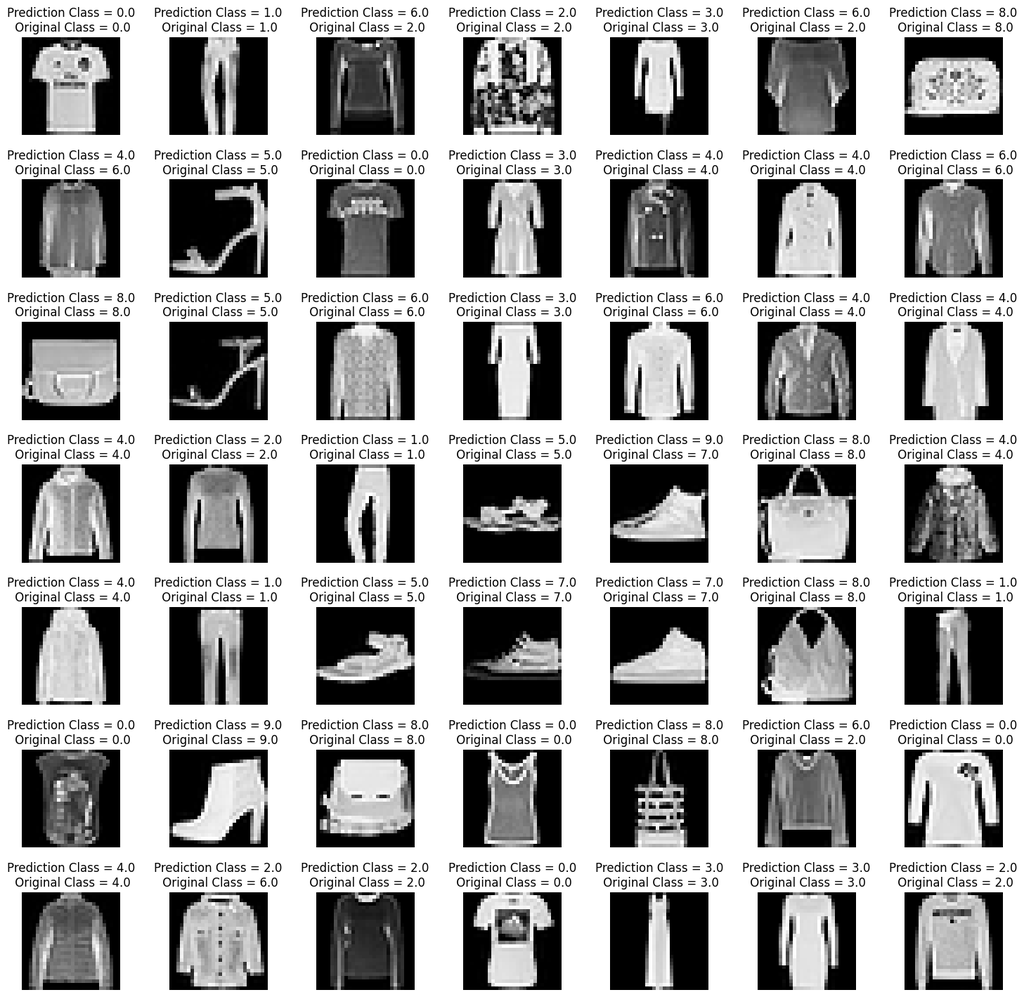

```python
L = 7
W = 7
fig, axes = plt.subplots(L, W, figsize = (18,18))
axes = axes.ravel()

for i in np.arange(0, L * W):
    axes[i].imshow(X_test[i].reshape(28,28), cmap='gray')
    axes[i].set_title(f"Prediction Class = {predicted_classes_test[i]:0.1f}\n Original Class = {y_test[i]:0.1f}")
    axes[i].axis('off')

plt.subplots_adjust(wspace=0.5)
```

## 6. High Precision for class 5:

We saw earlier that for test data:  
Precision: 0.98  
Recall: 0.92

To increase the precision without changing or retraining model, we studied that we need to **increase threshold**.

```python
y_scores = y_test_pred[:, 5]
y5 = (y_test == 5)

threshold = 0.6
y_pred_high_precision = (y_scores > threshold)

precision = precision_score(y5, y_pred_high_precision)
recall = recall_score(y5, y_pred_high_precision)

print(f"When threshold increased to: {threshold}\nPrecision: {precision:.4f}\nRecall: {recall:.4f}")
```

```
When threshold increased to: 0.6
Precision: 0.9901
Recall: 0.9040
```

By doing this the precision value increased from 0.98 to **0.99**.  
Precision increases because the values with high confidence of being positive will be classified and recall i.e the ratio (tp/tp+np) decreases.

## 7. High Recall for Class 5:

To increase the recall value, **decrease threshold**

```python
y_scores = y_test_pred[:, 5]
y5 = (y_test == 5)

threshold = 0.3
y_pred_high_recall = (y_scores > threshold)

precision = precision_score(y5, y_pred_high_recall)
recall = recall_score(y5, y_pred_high_recall)

print(f"When threshold decreased to: {threshold}\nPrecision: {precision:.4f}\nRecall: {recall:.4f}")
```

```
When threshold decreased to: 0.3
Precision: 0.9790
Recall: 0.9340
```

Recall increased from 0.92 to **0.93**  
When the threshold value is decreased, recall increases whereas precision decreases.  
It is because all those which had low predicted probability of will also be classified as positive.

References:

https://github.com/CSCN8010/CSCN8010/blob/main/class_notebooks/datasets/mnist.ipynb  
https://github.com/CSCN8010/CSCN8010/blob/main/dl_class_notebooks/03A_minimal_mnist_keras.ipynb  
https://www.kaggle.com/code/pavansanagapati/a-simple-cnn-model-beginner-guide